# 16.09.2015 Notes for STAT 330

Robert Lee

September 16, 2015

# Chapter 3; Random variables

A random variable is a real-valued function on the sample space $\Omega$.

We write $X(\omega)$, $\omega \in \Omega$, for a random variable, or simply $X$ with $\omega$ suppressed.

> Examples
1. Roll two dice. Let $X$ be the sum.
2. Flip a coin 11 times. Let $X$ be the number of heads.
3. Let $X$ be the number of tosses required to get the 1st heads.
4. Waiting time for a bus.
5. The closing price of the TSX tomorrow.

### Cumulative distribution function

One useful tool for studying a random variable is the cumulative distribution function (cdf), defined as

$F(x) = P(X \leq x)$, for any real $x$,

which has the following properties:

1. $F(x)$ is non-decreasing, i.e.

   $F(x_1) \leq F(x_2)$ for any $x_1 < x_2$
2. $lim_{x\to-\infty} F(x) = 0$.
3. $lim_{x\to+\infty} F(x) = 1$.
4. $F(x)$ is *right continuous*.

> Example 1 (of *right continuous*)

A fair coin is flipped three times. Let $X$ be the number of heads. Obviously,

$X = 0, 1, 2, 3$ ,

with $P(X = 0) = P(X = 3) = \displaystyle \frac{1}{8}$, $P(X = 1) = P(X = 2) = \displaystyle \frac{3}{8}$.

> Diagram 1

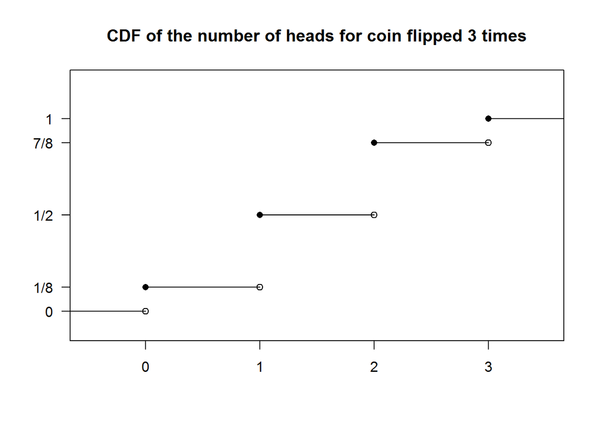

$F(0) = P(X \leq 0) = \displaystyle \frac{1}{8}$

$F(0.5) = P(X \leq 0.5) = \displaystyle \frac{1}{8}$

```
 I think I'm missing something here.  Please
 notify me if your notes show what it is.
```

## Discrete random variables

A random variable is discrete if the set of all possible values is finite or countably infinite (read: countable).

```
 Countable -- can be put in a sequence.  Eg. The set of all positive integers is coutable -- 1, 2, 3, 4, 5, ...
 Integers too -- they can be put in a sequence.
 Rational numbers can be put in a sequence too.
 Real numbers cannot.
 Poisson distribution, geometric distributions too -- can count the values.
```

Such random variable are bests studied using the probability mass function (pmf), defined as $p(x) = P(X = x)$, $x = x_1, x_2, x_3,$…, where $x_1, x_2, x_3$, … are the possible values of X.

> Example 1

Let $X$ be the pdf of heads when a fair coins is flipped 11 times.

and $p(x) = P(X = x)) = \displaystyle \frac{11\choose x}{2^{11}}$, $x = 0, 1, 2,$ …$11$.

> Example 2

5 cards from 52 cards. Let $X$ be the number of red cards.

$X = 0,1,2,3,4,5$.

$p(x) = P(X = x) = \displaystyle \frac{{26\choose x}{26 \choose{5-x}}}{52 \choose 5}$, $x = 0, 1, 2, 3, 4, 5$.

> Example 3

Repeatedlly toss a fair coin until a head occurs. Let $X$ be the number of tosses.

$X = 1, 2, 3, 4,$…

$p(x) = P(X = x) = \displaystyle \frac{1}{2^x}$, $x = 1, 2, 3, 4,...$